# STAT-S676

Assignment 1

John Koo

See source code here: https://github.com/johneverettkoo/stats-hw

# Problem 1

AIC is given by $-2 \log(L(\hat{\theta}|y)) + 2K$ where $L$ is the likelihood function. We are given that $Y \sim \mathcal{N}(X \beta, \sigma^2 I)$. Then $\varepsilon = Y - X \beta \sim \mathcal(0, \sigma^2 I)$. Therefore, the pdf of $\varepsilon$ is a multivariate normal $f(\varepsilon) = \big( \frac{1}{2 \pi \sigma^2} \big)^{n/2} e^{-\frac{1}{2 \sigma^2} \varepsilon^T \varepsilon}$. $\varepsilon^T \varepsilon = RSS = n \hat{\sigma}^2 \approx n \sigma^2$. (We sub in the estimate for the parameter.) Then we get $L = \big( \frac{1}{2 \pi \sigma^2} \big)^{n/2} e^{-\frac{n}{2}}$. Plugging this in for $L$, we get:

$$AIC = -2 \log
\bigg( \Big( \frac{1}{2 \pi \sigma^2} \Big)^{n/2} e^{-\frac{n}{2}} \bigg) +
2K$$
$$= -2
\bigg(-\frac{n}{2} \log(2 \pi) - \frac{n}{2} \log(\sigma^2) - \frac{n}{2} \bigg)
+ 2K$$
$$= n \log(2 \pi) + n \log(\sigma^2) + n + 2K$$

We can ignore the two terms $n \log(2\pi)$ and $n$ since they are fixed for some particular dataset.

# Problem 2

We have the following components for $y$, $\beta$, and $\sigma^2$:

$$f(y|\beta, \sigma^2) = \Big( \frac{1}{2 \pi \sigma^2} \Big)^{n/2}
e^{-\frac{(y - X \beta)^T (y - X \beta)}{2 \sigma^2}}$$

$$f(\beta | \sigma^2) =
\frac{\big| X^T X \big|^{1/2}}{(2 \pi n \sigma^2)^{p/2}}
e^{-\frac{(X \beta)^T (X \beta)}{2 n \sigma^2}}$$

$$f_{\sigma^2}(\sigma^2) =
\Big( \frac{1}{2 \pi (\sigma^2)^3} \Big)^{1/2}
e^{-\frac{1}{2 \sigma^2}}$$

Then

$$f(y, \beta, \sigma^2) =
(y|\beta, \sigma^2) \times f(\beta | \sigma^2) \times f_{\sigma^2}(\sigma^2)$$

And to compute the marginal for $Y$:

$$f_Y(y) = \int_{\beta, \sigma^2} f(y, \beta, \sigma^2) d\beta d\sigma^2$$

$$\bigg(\frac{1}{2 \pi \sigma^2} \bigg)^{n/2}
\bigg(\frac{\Big| X^T X \Big|}{(2 \pi n \sigma^2)^{p}} \bigg)^{1/2}
\bigg( \frac{1}{2 \pi (\sigma^2)^3} \bigg)^{1/2}
\exp \bigg( -\frac{1}{2 \sigma^2}
\Big( (y - X \beta)^T (y - X \beta) +
\frac{1}{n} \beta^T X^T X \beta + 1 \Big)\bigg)$$

Then rearranging the terms inside the exponent:

$$-\frac{1}{2 \sigma^2} \bigg(
\big( \beta - \hat{\beta} \frac{n}{n+1} \big)^T
\big( X^T X (1 + \frac{1}{n}) \big)
\big( \beta - \hat{\beta} \frac{n}{n+1} \big) +
y^T \big( I - \frac{n}{n+1} H \big) y + 1
\bigg)$$

Where $\hat{\beta} = (X^T X)^{-1} X^T y$ and $H = X (X^T X)^{-1} X^T$.

Then we can see that $\Sigma_{\beta} = \sigma^2 \frac{n}{n+1} (X^T X)^{-1}$. Then integrating w.r.t. $\beta$, we get a factor of $\big( (2 \pi)^p (\sigma^2)^p (\frac{n}{n+1})^p / \big| X^T X \big| \big)^{1/2}$, which leaves us with:

$$f_{Y, \sigma^2} = \bigg(\frac{1}{2 \pi \sigma^2} \bigg)^{n/2 + 1/2}
\bigg( \frac{1}{n+1} \bigg)^{p/2}
(\sigma^2)^{-\frac{3}{2} - \frac{n}{2}}
\exp \bigg(-\frac{1}{2 \sigma^2}
\Big(y^T \big(I - \frac{n}{n+1} H \big) y + 1 \Big) \bigg)$$

Integrating out $\sigma^2$, we obtain:

$$\bigg(\frac{1}{2 \pi} \bigg)^{\frac{n+1}{2}}
\bigg(\frac{1}{n+1} \bigg)^{p/2}
\frac{\Gamma(\frac{n+1}{2})}
{\Big(\frac{1}{2} y^T (I - \frac{n}{n+1}H)y + 1/2\Big)^{\frac{n+1}{2}}}$$

# Problem 3

TIC is defined by $-2 \log L + 2 tr(J(\theta) I(\theta^{-1}))$. $L(\theta|y) = g(y|\theta)$ where $I = \nabla_{\theta} \nabla_{\theta}^T l$ and $J = (\nabla_{\theta})^T (\nabla_{\theta})$. In terms of partial derivatives, this becomes:

$$I = -E_{truth}\begin{bmatrix}
\frac{\partial^2 l}{\partial \beta \partial \beta^T} &
\frac{\partial^2 l}{\partial \beta \partial \sigma^2} \\
\frac{\partial^2 l}{\partial \sigma^2 \partial \beta^T}&
\frac{\partial^2 l}{\partial (\sigma^2)^2}
\end{bmatrix}$$

$$J = E_{truth}\begin{bmatrix}
(\partial_{\beta} l) (\partial_{\beta} l)^T &
(\partial_{\beta} l) (\partial_{\sigma^2} l)^T \\
(\partial_{\sigma^2} l) (\partial_{\beta^2} l)^T &
(\partial_{\sigma^2} l) (\partial_{\sigma^2} l)^T
\end{bmatrix}$$

Then computing the partial derivatives:

$$\frac{\partial l}{\partial \beta} = \frac{(y - X \beta)^T X}{\sigma^2}$$
$$\frac{\partial l}{\partial \sigma^2} =
-\frac{1}{2 \sigma^2} + \frac{1}{2 (\sigma^2)^2} (y - X \beta)^T (y - X \beta)$$
$$\frac{\partial^2 l}{\partial \beta \beta^T} = -\frac{X^T X}{\sigma^2}$$
$$\frac{\partial^2 l}{\partial \beta \sigma^2} =
-\frac{(y - X \beta)^T X}{(\sigma^2)^2}$$
$$\frac{\partial^2 l}{\partial (\sigma^2)^2} =
\frac{1}{2 (\sigma^2)^2} -
\frac{1}{(\sigma^2)^3} (y - X \beta)^T (y - X \beta)$$

Noting that $y \sim \mathcal{N}(\mu, \sigma^2 I)$, taking the expectations, we arrive at:

$$I = \frac{1}{\sigma^2}\begin{bmatrix}
X^T X &
\frac{X^T (\mu - X \beta)}{\sigma^2} \\
\frac{(\mu - X \beta)^T X}{\sigma^2} &
-\frac{1}{2 \sigma^2} + \frac{\sigma^2 +
(\mu - X \beta)^T (\mu - X \beta)}{(\sigma^2)^2}
\end{bmatrix}$$

Where the numerator of the second term of $[I]_{22}$ was derived as follows: $(y - X \beta)^T (y - X \beta) = (y - \mu + \mu - X \beta)^T (y - \mu + \mu - X \beta) = (y - \mu)^T (y - \mu) + (\mu - X \beta)^T (\mu - X \beta) + 2 (y - \mu)^T (\mu - X \beta)$. Then taking the expectation of this, the first term becomes $\sigma^2$, the second term stays the same, and the last term goes to 0 since $E[y] = \mu$.

In order to compute $J$, we need the following:

$$[J]_{11} =
E \Big[ \frac{1}{(\sigma^2)^2} X^T (y - X \beta) (y - X \beta)^T X \Big]$$

The employing the same trick as before, the middle part becomes:

$$(y - \mu + \mu - X \beta) (y - \mu + \mu - X \beta)^T$$
$$= (y - \mu) (y - \mu)^T + (y - \mu)(\mu - X \beta)^T +
(\mu - X \beta)(y - \mu)^T + (\mu - X \beta)(\mu - X \beta)^T$$

Under the expectation, the middle two terms go to 0 since $E[y] = \mu$. The first term also turns into $\sigma^2 I$. Then we get:

$$[J]_{11} = \frac{1}{(\sigma^2)^2}
X^T (\sigma^2 I + (\mu - X \beta)(\mu - X \beta)^T) X$$

For $[J]_{22}$, we compute $\Big(\frac{\partial^2 l}{\partial(\sigma^2)^2}\Big)^2$ then take the expected value. We can say that the odd powers go to zero under the expectation since the normal is symmetric. Then we get:

$$\frac{1}{4 (\sigma^2)^2} \Bigg(
1 - \frac{2}{\sigma^2} \big(\sigma^2 + (\mu - X \beta)^2 \big) +
\frac{1}{(\sigma^2)^2}
\big(3(\sigma^2)^2 +
6 \sigma^2 (\mu - X \beta)^T (\mu - X \beta) +
((\mu - X \beta)^T (\mu - X \beta)^T)^2 \big)
\Bigg)$$

For the $[J]_{12} = (\frac{\partial l}{\partial \beta}) (\frac{\partial l}{\partial \sigma^2})^T$ term:

$$(\frac{\partial l}{\partial \beta}) (\frac{\partial l}{\partial \sigma^2})^T =
\frac{1}{2 (\sigma^2)^2} (y - X \beta)^T X
\bigg(-1 + \frac{1}{\sigma^2} (y - X \beta)^T (y - X \beta) \bigg)$$

Taking the expectation of this *should* yield:

$$\frac{1}{2 (\sigma^2)^2} \bigg(
(\mu - X \beta) + \frac{1}{\sigma^2}
(3 \sigma^2 (\mu - X \beta) + (\mu - X \beta)^T (\mu - X \beta) (\mu - X \beta)^T
\bigg)$$

$[J]_{21}$ is just the transpose of $[J]_{12}$.

# Problem 4

From the textbook, we get the TIC for $tr(J I^{-1})$ assuming $Y - X \beta \sim \mathcal{N}(0, \sigma^2 I)$:

$$tr(J I^{-1}) = \frac{\sigma^2}{\hat{\sigma}^2}
\Bigg(K + 1 + \frac{\sigma^2}{\hat{\sigma}^2} (\frac{\gamma-1}{2} - 2)\Bigg)$$

Where $\gamma = \frac{E[\varepsilon^4]}{E[\varepsilon^2]^2}$. Since we don’t know the parameter $\sigma^2$, we will just sub in the estimate. Then this turns into:

$$K + \frac{\gamma-1}{2} - 1$$

This is nowhere near “efficient” …

```r
# packages, etc.
import::from(magrittr, `%>%`, `%<>%`)
dp <- loadNamespace('dplyr')
import::from(purrr, flatten)
import::from(foreach, foreach, `%dopar%`)
library(ggplot2)
theme_set(theme_bw())
import::from(parallel, mclapply, detectCores)

# mc stuff
options(mc.cores = detectCores())

# tic function
# no documentation b/c lazy
# but it takes a lm output and returns a number
TIC <- function(linear.model) {
  # find the log likelihood estimate
  l <- as.numeric(logLik(linear.model))

  # number of beta parameters
  K <- length(linear.model$coefficients)

  # gamma from data
  g <- mean(linear.model$residuals ** 4) /
    mean(linear.model$residuals ** 2) ** 2

  # return TIC
  -2 * l + 2 * (K + (g - 1) / 2) - 1

  # # the inputs
  # X <- as.matrix(cbind(1, linear.model$model[, -1]))
  # # the targets
  # y <- linear.model$model[, 1]
  # # sigma estimate
  # s <- sigma(linear.model)
  # # coefficient estimates
  # coefs <- linear.model$coefficients
  # # number of rows
  # n <- nrow(X)
  #
  # # compute I
  # I. <- rbind(cbind(t(X) %*% X / s^2, t(X) %*% (mean(y) - X %*% coefs) / s^4),
  #             cbind(t(mean(y) - X %*% coefs) %*% X / s^4, 1 / 2 / s^4)) / n
  #
  # # compute J
  # d.beta <- t(y - X %*% coefs) %*% X / s^2
  # d.s2 <- as.numeric(1 / 2 / s^4 -
  #                      t(y - X %*% coefs) %*% (y - X %*% coefs) / 2 / s^4)
  # J <- rbind(cbind(t(d.beta) %*% d.beta, t(d.beta) * d.s2),
  #            cbind(d.beta * d.s2, d.s2 ** 2)) / n
  #
  # # compute TIC
  # -2 * l + 2 * sum(diag(J %*% solve(I.)))
}

# get the data
load('~/dev/stats-hw/stat-s676/diabetes2.Rdata')

# "sex^2" is a linear combination of other variables
# just going to remove it
diabetes2 %<>% dp$select(-`sex^2`)

# vector of predictors
predictors <- diabetes2 %>%
  dp$select(-y) %>%
  colnames()

# list of predictor sets
predictor.sets <- lapply(seq(length(predictors)), function(i) {
  combn(predictors, i, simplify = FALSE)
}) %>%
  flatten()

t0 <- Sys.time()
# data frame of results
out.df <- mclapply(predictor.sets, function(p) {
  # subset to predictor set
  temp.df <- diabetes2 %>%
    dp$select(c('y', p))

  # create the model
  temp.mod <- lm(y ~ ., data = temp.df)

  # compute TIC
  tic <- TIC(temp.mod)

  # compute AIC
  aic <- AIC(temp.mod)

  # compute BIC
  bic <- BIC(temp.mod)

  # combine into data frame
  dplyr::data_frame(AIC = aic,
                    BIC = bic,
                    TIC = tic,
                    p = length(temp.mod$coefficients))
}) %>%
  dp$bind_rows()
Sys.time() - t0
```

```
Time difference of 27.22075 mins
```

```r
# predictor set with lowest TIC
predictor.sets[[which.min(out.df$TIC)]]
```

```
 [1] "sex"   "bmi"   "map"   "tc"    "ldl"   "hdl"   "ltg"   "age^2"
 [9] "bmi^2" "ltg^2" "glu^2"
```

```r
# predictor set with lowest AIC
predictor.sets[[which.min(out.df$AIC)]]
```

```
 [1] "sex"   "bmi"   "map"   "tc"    "ldl"   "hdl"   "ltg"   "age^2"
 [9] "bmi^2" "ltg^2" "glu^2"
```

```r
# predictor set with lowest BIC
predictor.sets[[which.min(out.df$BIC)]]
```

```
[1] "sex"   "bmi"   "map"   "tc"    "ldl"   "ltg"   "glu^2"
```

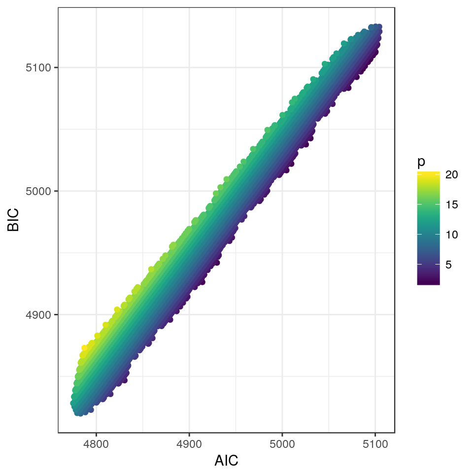

```r
# probably can't see much from this
ggplot(out.df) +
  geom_point(aes(x = AIC, y = BIC, colour = p)) +
  viridis::scale_colour_viridis()
```

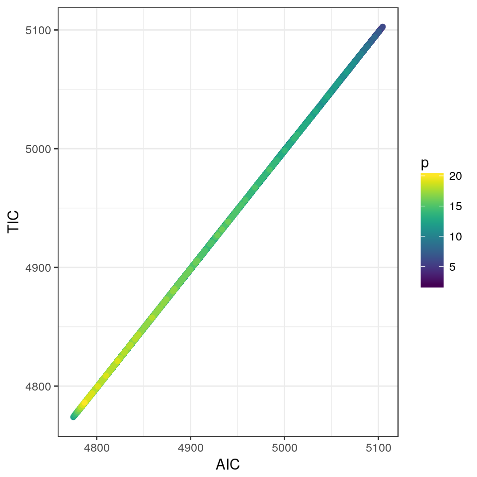

```r
ggplot(out.df) +
  geom_point(aes(x = AIC, y = TIC, colour = p)) +
  viridis::scale_colour_viridis()
```